# Capstone_Cyclistic

Ellen

2022-09-25

## Introduction

This is a report on my first capstone project from Google Data Analytics Course on the Cyclistic bike-share analysis case study.

Cyclistic is a fictional bike-sharing company that is based in Chicago. The company want to understand how casual riders and annual members use Cyclistic bikes differently. From these insights, they will then design a new marketing strategy to convert casual riders into annual members. The question we need to answer is How do annual members and casual riders use Cyclistic bikes differently.

## Cleaning Up Data

After i downloaded said files, i convert them to .xlsx file and then do some data cleaning such as:

- Adding ride_length column with formula (=Ended_Time-Started_Time)
- Adding day_of_week column with formula (=Text(Started_Time;“dddd”)
- Adding month_ride column with formula (=Text(Started_Time;“mmyy”)

Now the excel data are ready to be analyzed with R. The Reason i chose R in this project is because of the data size, plus i want to familiarize myself with R.

## Starting in R

This is the library i will be using in this project:

```r
library(tidyverse)
```

```r
library(ggplot2)
library(lubridate)
library(readxl)
```

then i will be importing the .xlsx data such as:

```r
aug21 <- read_excel("data202108.xlsx")
sep21 <- read_excel("data202109.xlsx")
okt21 <- read_excel("data202110.xlsx")
nov21 <- read_excel("data202111.xlsx")
dec21 <- read_excel("data202112.xlsx")
jan22 <- read_excel("data202201.xlsx")
feb22 <- read_excel("data202202.xlsx")
mar22 <- read_excel("data202203.xlsx")
apr22 <- read_excel("data202204.xlsx")
may22 <- read_excel("data202205.xlsx")
jun22 <- read_excel("data202206.xlsx")
jul22 <- read_excel("data202207.xlsx")
aug22 <- read_excel("data202208.xlsx")
```

the data imported will have structure as below, example (aug21 data)

```r
str (aug21)
```

```
## tibble [804,352 × 16] (S3: tbl_df/tbl/data.frame)
##  $ ride_id           : chr [1:804352] "99103BB87CC6C1BB" "EAFCCCFB0A3FC5A1" "9EF4F46C57AD234D" "5834D3208BFAF1DA" ...
##  $ rideable_type     : chr [1:804352] "electric_bike" "electric_bike" "electric_bike" "electric_bike" ...
##  $ started_at        : POSIXct[1:804352], format: "2021-08-10 17:15:49" "2021-08-10 17:23:14" ...
##  $ ended_at          : POSIXct[1:804352], format: "2021-08-10 17:22:44" "2021-08-10 17:39:24" ...
##  $ start_station_name: chr [1:804352] NA NA NA NA ...
##  $ start_station_id  : chr [1:804352] NA NA NA NA ...
##  $ end_station_name  : chr [1:804352] NA NA NA NA ...
##  $ end_station_id    : chr [1:804352] NA NA NA NA ...
##  $ start_lat         : num [1:804352] 41.8 41.8 42 42 41.8 ...
##  $ start_lng         : num [1:804352] -87.7 -87.7 -87.7 -87.7 -87.6 ...
##  $ end_lat           : num [1:804352] 41.8 41.8 42 42 41.8 ...
##  $ end_lng           : num [1:804352] -87.7 -87.6 -87.7 -87.7 -87.6 ...
##  $ member_casual     : chr [1:804352] "member" "member" "member" "member" ...
##  $ ride_length       : POSIXct[1:804352], format: "1899-12-31 00:06:55" "1899-12-31 00:16:10" ...
##  $ day_of_week       : chr [1:804352] "Tuesday" "Tuesday" "Saturday" "Saturday" ...
##  $ month_ride        : chr [1:804352] "0821" "0821" "0821" "0821" ...
```

## Cleaning Data in R

The next step after importing the .xlsx data to R is cleaning the data. I will be omiting the row with empty data with :

```r
aug21 <- na.omit(aug21)
sep21 <- na.omit(sep21)
okt21 <- na.omit(okt21)
nov21 <- na.omit(nov21)
dec21 <- na.omit(dec21)
jan22 <- na.omit(jan22)
feb22 <- na.omit(feb22)
mar22 <- na.omit(mar22)
apr22 <- na.omit(apr22)
may22 <- na.omit(may22)
jun22 <- na.omit(jun22)
jul22 <- na.omit(jul22)
aug22 <- na.omit(aug22)
```

So, current data after being cleaned of empty data should be like:

```r
str (aug21)
```

```
## tibble [674,409 × 16] (S3: tbl_df/tbl/data.frame)
##  $ ride_id           : chr [1:674409] "DD06751C6019D865" "79973DC3B232048F" "0249AD4B258806AD" "F41EB054E44ACFDA" ...
##  $ rideable_type     : chr [1:674409] "classic_bike" "classic_bike" "classic_bike" "classic_bike" ...
##  $ started_at        : POSIXct[1:674409], format: "2021-08-08 17:21:26" "2021-08-27 08:53:52" ...
##  $ ended_at          : POSIXct[1:674409], format: "2021-08-08 17:25:37" "2021-08-27 09:18:29" ...
##  $ start_station_name: chr [1:674409] "Desplaines St & Kinzie St" "Larrabee St & Armitage Ave" "Aberdeen St & Jackson Blvd" "Michigan Ave & Oak St" ...
##  $ start_station_id  : chr [1:674409] "TA1306000003" "TA1309000006" "13157" "13042" ...
##  $ end_station_name  : chr [1:674409] "Kingsbury St & Kinzie St" "Michigan Ave & Oak St" "Aberdeen St & Jackson Blvd" "Michigan Ave & Oak St" ...
##  $ end_station_id    : chr [1:674409] "KA1503000043" "13042" "13157" "13042" ...
##  $ start_lat         : num [1:674409] 41.9 41.9 41.9 41.9 41.9 ...
##  $ start_lng         : num [1:674409] -87.6 -87.6 -87.7 -87.6 -87.6 ...
##  $ end_lat           : num [1:674409] 41.9 41.9 41.9 41.9 41.9 ...
##  $ end_lng           : num [1:674409] -87.6 -87.6 -87.7 -87.6 -87.6 ...
##  $ member_casual     : chr [1:674409] "member" "member" "member" "casual" ...
##  $ ride_length       : POSIXct[1:674409], format: "1899-12-31 00:04:11" "1899-12-31 00:24:37" ...
##  $ day_of_week       : chr [1:674409] "Sunday" "Friday" "Sunday" "Thursday" ...
##  $ month_ride        : chr [1:674409] "0821" "0821" "0821" "0821" ...
##  - attr(*, "na.action")= 'omit' Named int [1:129943] 1 2 3 4 5 6 7 8 9 10 ...
##   ..- attr(*, "names")= chr [1:129943] "1" "2" "3" "4" ...
```

After omiting empty row data, i will convert the ride_length column to minutes because after importing the excel data to R, i found the column to be structured as datetime type.

I will convert the data like this:

```r
aug21$ride_length <-
  minute(aug21$ride_length) + 60 * hour(aug21$ride_length)
sep21$ride_length <-
  minute(sep21$ride_length) + 60 * hour(sep21$ride_length)
okt21$ride_length <-
  minute(okt21$ride_length) + 60 * hour(okt21$ride_length)
nov21$ride_length <-
  minute(nov21$ride_length) + 60 * hour(nov21$ride_length)
dec21$ride_length <-
  minute(dec21$ride_length) + 60 * hour(dec21$ride_length)
jan22$ride_length <-
  minute(jan22$ride_length) + 60 * hour(jan22$ride_length)
feb22$ride_length <-
  minute(feb22$ride_length) + 60 * hour(feb22$ride_length)
mar22$ride_length <-
  minute(mar22$ride_length) + 60 * hour(mar22$ride_length)
apr22$ride_length <-
  minute(apr22$ride_length) + 60 * hour(apr22$ride_length)
may22$ride_length <-
  minute(may22$ride_length) + 60 * hour(may22$ride_length)
jun22$ride_length <-
  minute(jun22$ride_length) + 60 * hour(jun22$ride_length)
jul22$ride_length <-
  minute(jul22$ride_length) + 60 * hour(jul22$ride_length)
aug22$ride_length <-
  minute(aug22$ride_length) + 60 * hour(aug22$ride_length)
```

And current data should look like this:

```r
str (aug21)
```

```
## tibble [674,409 × 16] (S3: tbl_df/tbl/data.frame)
##  $ ride_id           : chr [1:674409] "DD06751C6019D865" "79973DC3B232048F" "0249AD4B258806AD" "F41EB054E44ACFDA" ...
##  $ rideable_type     : chr [1:674409] "classic_bike" "classic_bike" "classic_bike" "classic_bike" ...
##  $ started_at        : POSIXct[1:674409], format: "2021-08-08 17:21:26" "2021-08-27 08:53:52" ...
##  $ ended_at          : POSIXct[1:674409], format: "2021-08-08 17:25:37" "2021-08-27 09:18:29" ...
##  $ start_station_name: chr [1:674409] "Desplaines St & Kinzie St" "Larrabee St & Armitage Ave" "Aberdeen St & Jackson Blvd" "Michigan Ave & Oak St" ...
##  $ start_station_id  : chr [1:674409] "TA1306000003" "TA1309000006" "13157" "13042" ...
##  $ end_station_name  : chr [1:674409] "Kingsbury St & Kinzie St" "Michigan Ave & Oak St" "Aberdeen St & Jackson Blvd" "Michigan Ave & Oak St" ...
##  $ end_station_id    : chr [1:674409] "KA1503000043" "13042" "13157" "13042" ...
##  $ start_lat         : num [1:674409] 41.9 41.9 41.9 41.9 41.9 ...
##  $ start_lng         : num [1:674409] -87.6 -87.6 -87.7 -87.6 -87.6 ...
##  $ end_lat           : num [1:674409] 41.9 41.9 41.9 41.9 41.9 ...
##  $ end_lng           : num [1:674409] -87.6 -87.6 -87.7 -87.6 -87.6 ...
##  $ member_casual     : chr [1:674409] "member" "member" "member" "casual" ...
##  $ ride_length       : num [1:674409] 4 24 0 4 35 40 1 54 58 20 ...
##  $ day_of_week       : chr [1:674409] "Sunday" "Friday" "Sunday" "Thursday" ...
##  $ month_ride        : chr [1:674409] "0821" "0821" "0821" "0821" ...
##  - attr(*, "na.action")= 'omit' Named int [1:129943] 1 2 3 4 5 6 7 8 9 10 ...
##   ..- attr(*, "names")= chr [1:129943] "1" "2" "3" "4" ...
```

Then i will order the day_of_week column level so i can have identical visualization result, i will sort the day_of_week column with:

```r
aug21$day_of_week <-
  ordered(
    aug21$day_of_week,
    levels = c(
      "Monday",
      "Tuesday",
      "Wednesday",
      "Thursday",
      "Friday",
      "Saturday",
      "Sunday"
    )
  )
sep21$day_of_week <-
  ordered(
    sep21$day_of_week,
    levels = c(
      "Monday",
      "Tuesday",
      "Wednesday",
      "Thursday",
      "Friday",
      "Saturday",
      "Sunday"
    )
  )
okt21$day_of_week <-
  ordered(
    okt21$day_of_week,
    levels = c(
      "Monday",
      "Tuesday",
      "Wednesday",
      "Thursday",
      "Friday",
      "Saturday",
      "Sunday"
    )
  )
nov21$day_of_week <-
  ordered(
    nov21$day_of_week,
    levels = c(
      "Monday",
      "Tuesday",
      "Wednesday",
      "Thursday",
      "Friday",
      "Saturday",
      "Sunday"
    )
  )
dec21$day_of_week <-
  ordered(
    dec21$day_of_week,
    levels = c(
      "Monday",
      "Tuesday",
      "Wednesday",
      "Thursday",
      "Friday",
      "Saturday",
      "Sunday"
    )
  )
jan22$day_of_week <-
  ordered(
    jan22$day_of_week,
    levels = c(
      "Monday",
      "Tuesday",
      "Wednesday",
      "Thursday",
      "Friday",
      "Saturday",
      "Sunday"
    )
  )
feb22$day_of_week <-
  ordered(
    feb22$day_of_week,
    levels = c(
      "Monday",
      "Tuesday",
      "Wednesday",
      "Thursday",
      "Friday",
      "Saturday",
      "Sunday"
    )
  )
mar22$day_of_week <-
  ordered(
    mar22$day_of_week,
    levels = c(
      "Monday",
      "Tuesday",
      "Wednesday",
      "Thursday",
      "Friday",
      "Saturday",
      "Sunday"
    )
  )
apr22$day_of_week <-
  ordered(
    apr22$day_of_week,
    levels = c(
      "Monday",
      "Tuesday",
      "Wednesday",
      "Thursday",
      "Friday",
      "Saturday",
      "Sunday"
    )
  )
may22$day_of_week <-
  ordered(
    may22$day_of_week,
    levels = c(
      "Monday",
      "Tuesday",
      "Wednesday",
      "Thursday",
      "Friday",
      "Saturday",
      "Sunday"
    )
  )
jun22$day_of_week <-
  ordered(
    jun22$day_of_week,
    levels = c(
      "Monday",
      "Tuesday",
      "Wednesday",
      "Thursday",
      "Friday",
      "Saturday",
      "Sunday"
    )
  )
jul22$day_of_week <-
  ordered(
    jul22$day_of_week,
    levels = c(
      "Monday",
      "Tuesday",
      "Wednesday",
      "Thursday",
      "Friday",
      "Saturday",
      "Sunday"
    )
  )
aug22$day_of_week <-
  ordered(
    aug22$day_of_week,
    levels = c(
      "Monday",
      "Tuesday",
      "Wednesday",
      "Thursday",
      "Friday",
      "Saturday",
      "Sunday"
    )
  )
```

## Merging all months data

```r
data_combined <-
  rbind(aug21,
        sep21,
        okt21,
        nov21,
        dec21,
        jan22,
        feb22,
        mar22,
        apr22,
        may22,
        jun22,
        jul22,
        aug22)
```

and order the month_ride column level

```r
data_combined$month_ride <-
  ordered(
    data_combined$month_ride,
    levels = c(
      "0821",
      "0921",
      "1021",
      "1121",
      "1221",
      "0122",
      "0222",
      "0322",
      "0422",
      "0522",
      "0622",
      "0722",
      "0822"
    )
  )
```

## Analyzing Data

#### (Monthly) Total Ride Count by Customer type per Weekdays

First, i will be looking at how much each customer type rides throughout the weeks monthly, but i will only include visualization for August 2021 in this report.

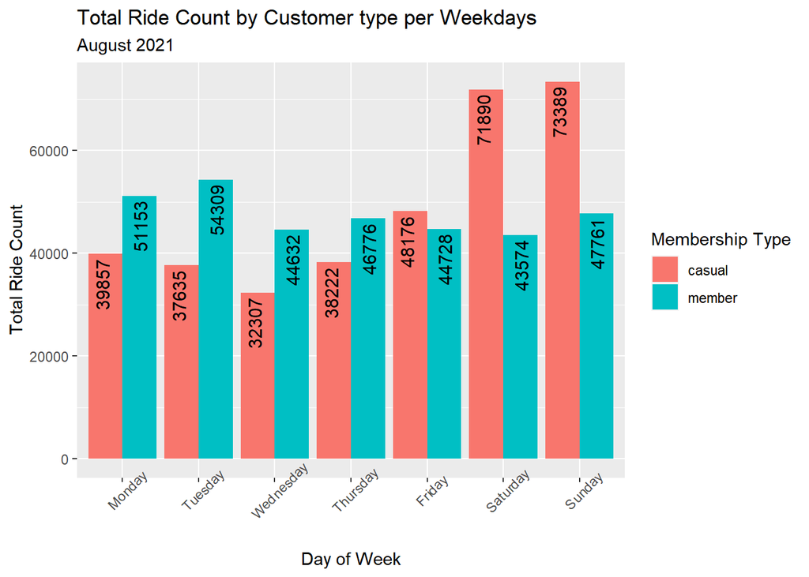

```r
aug21 %>%
  group_by(member_casual, day_of_week) %>%
  summarise(total_rides = n()) %>%
  ggplot(aes(x = day_of_week, y = total_rides, fill = member_casual)) +
  geom_col(position = position_dodge (width = 0.9) , width = 0.9) + labs (
    x = "Day of Week",
    y = "Total Ride Count",
    title = "Total Ride Count by Customer type per Weekdays",
    subtitle = "August 2021",
    fill = "Membership Type"
  ) +
  geom_text(
    aes(label = total_rides, angle = 90),
    position = position_dodge(1),
    vjust = 0.4,
    hjust = 1.1,
    size = 4
  ) +
  theme(axis.text.x = element_text (angle = 45))
```

#### (Monthly) Average Minutes per ride by Customer type on Weekdays

Secondly, i will be looking at the average minutes each customer type rides throughout the weeks monthly, but i will only include visualization for August 2021 in this report.

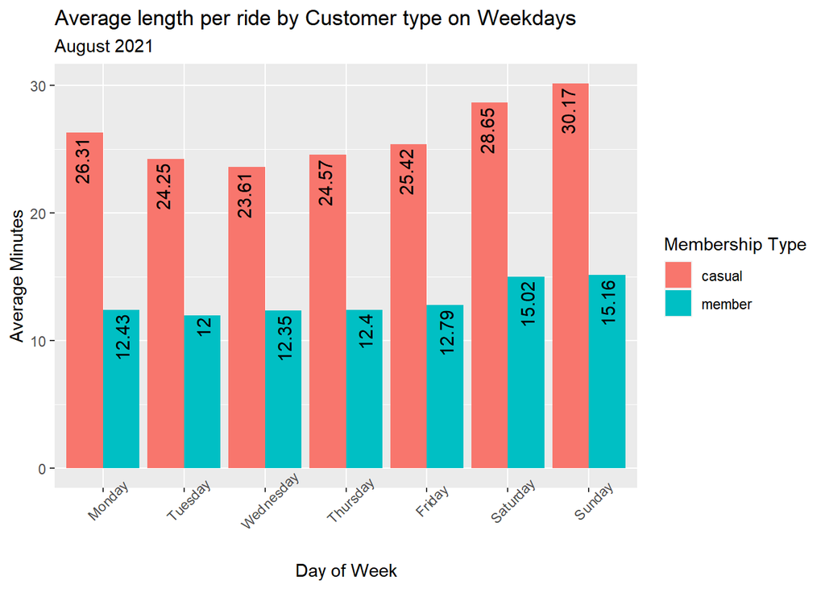

```r
aug21 %>%
  group_by(member_casual, day_of_week) %>%
  summarise(average_minutes = round(mean(ride_length), digits = 2)) %>%
  ggplot(aes(x = day_of_week, y = average_minutes, fill = member_casual)) +
  geom_col(position = position_dodge (width = 0.9) , width = 0.9) + labs (
    x = "Day of Week",
    y = "Average Minutes",
    title = "Average length per ride by Customer type on Weekdays",
    subtitle = "August 2021",
    fill = "Membership Type"
  ) +
  geom_text(
    aes(label = average_minutes, angle = 90),
    position = position_dodge(1),
    vjust = 0.4,
    hjust = 1.1,
    size = 4
  ) +
  theme(axis.text.x = element_text (angle = 45))
```

Conclusion 1 based on total rides and average minutes per days:

- Casual riders number tend to rise on the weekends, whereas member riders have steady numbers throughout the week.
- Casual riders have almost 2x average minutes ride than member riders.

#### Difference between the casual rider and member rider

next i will be looking at how much each membership type riders are with:

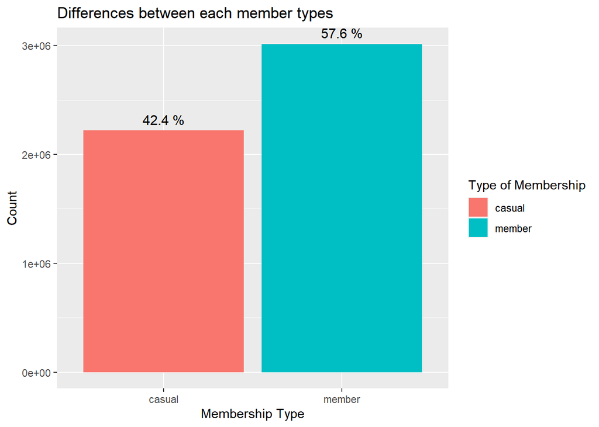

```r
data_combined %>%
  group_by(member_casual) %>%
  summarise(total_rides = n()) %>%
  mutate(perc = round(total_rides / sum(total_rides), 4)) %>%
  ggplot(aes(x = member_casual, y = total_rides, fill = member_casual)) +
  geom_bar(stat = "identity") + labs(
    x = "Membership Type",
    y = "Count",
    title = "Differences between each member types",
    fill = "Type of Membership"
  ) +
  geom_text(
    aes(label = paste(perc*100,"%")),
    position = position_dodge(1),
    vjust = -0.6,
    hjust = 0.5,
    size = 4
  )
```

Turns out 42.4% of the riders are casual members, this mean almost half of the riders are non-membership type.

#### (Yearly) Average ride length by Customer type and Day of Week

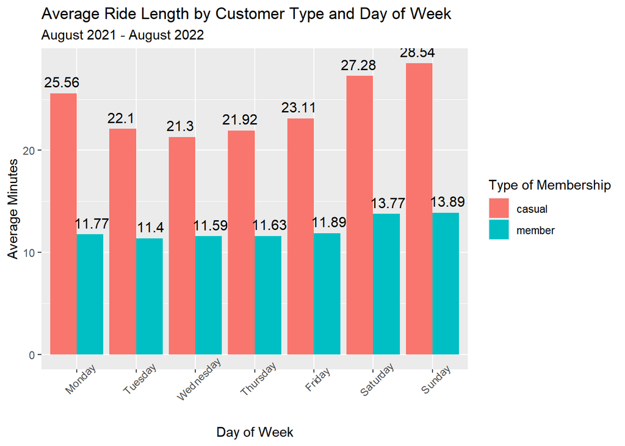

```r
data_combined %>%
  group_by(member_casual, day_of_week) %>%
  summarise(average_minutes = round(mean(ride_length), digits = 2)) %>%
  ggplot(aes(x = day_of_week, y = average_minutes, fill = member_casual)) +
  geom_col(position = "dodge") + labs (
    x = "Day of Week",
    y = "Average Minutes",
    title = "Average Ride Length by Customer Type and Day of Week",
    subtitle = "August 2021 - August 2022",
    fill = "Type of Membership"
  ) +
  geom_text(
    aes(label = average_minutes),
    position = position_dodge(1),
    vjust = -0.6,
    hjust = 0.5,
    size = 4
  ) +
  theme(axis.text.x = element_text (angle = 45))
```

The data here is not much different from the monthly one, the member riders have steady minutes throughout the week and the casual member have twice the average minutes of the member riders.

#### (Yearly) Total ride by Customer Type per days and months in the past 1 year

The next data i’ll be looking at is the total ride for each days, which can be seen as below

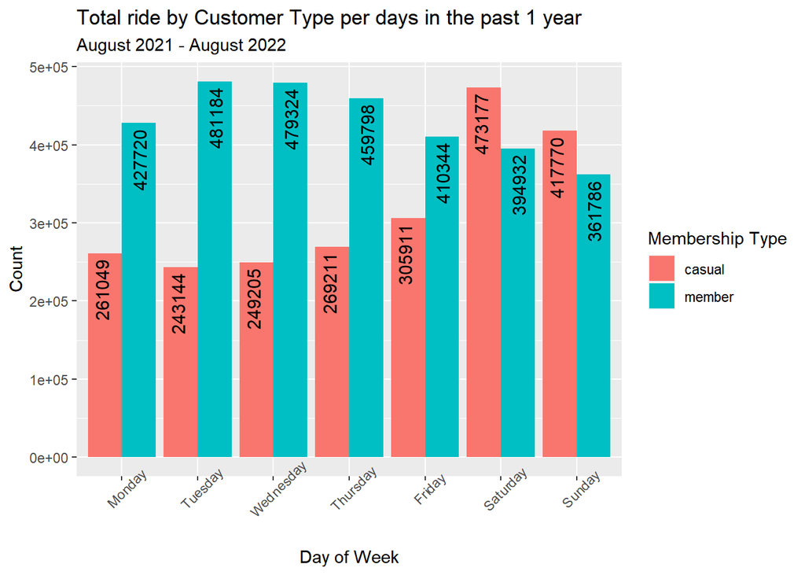

```r
data_combined %>%
  group_by(member_casual, day_of_week) %>%
  summarise(total_rides = n()) %>%
  ggplot(aes(x = day_of_week, y = total_rides, fill = member_casual)) +
  geom_col(position = position_dodge (width = 0.9) , width = 0.9) + labs (
    x = "Day of Week",
    y = "Count",
    title = "Total ride by Customer Type per days in the past 1 year",
    subtitle = "August 2021 - August 2022",
    fill = "Membership Type"
  ) +
  geom_text(
    aes(label = total_rides, angle = 90),
    position = position_dodge(1),
    vjust = 0.4,
    hjust = 1.1,
    size = 4
  ) +
  theme(axis.text.x = element_text (angle = 45))
```

and the total ride for each member types per month, as below

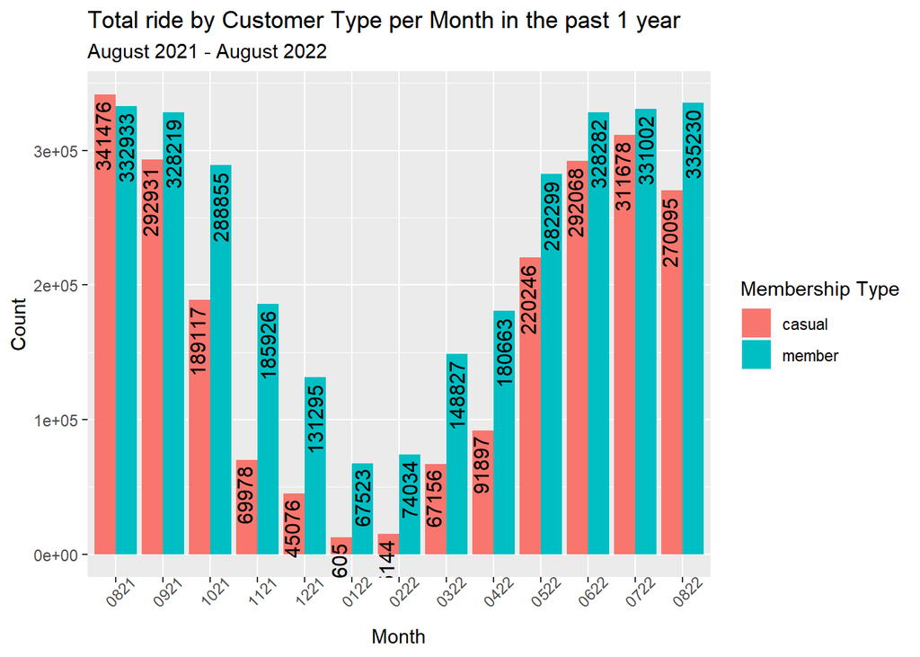

```r
data_combined %>%
  group_by(member_casual, month_ride) %>%
  summarise(total_rides = n()) %>%
  ggplot(aes(x = month_ride, y = total_rides, fill = member_casual)) +
  geom_col(position = position_dodge (width = 0.9) , width = 0.9) + labs (
    x = "Month",
    y = "Count",
    title = "Total ride by Customer Type per Month in the past 1 year",
    subtitle = "August 2021 - August 2022",
    fill = "Membership Type"
  ) +
  geom_text(
    aes(label = total_rides, angle = 90),
    position = position_dodge(1),
    vjust = 0.4,
    hjust = 1.1,
    size = 4
  ) +
  theme(axis.text.x = element_text (angle = 45))
```

based on these two graphs, we can see that casual member ride more on weekends and bike rides are not preferred in the colder months

#### Bicycle Type preferred by customer type in the past 1 year

And lastly i will be looking at the bike type preferred by each member type

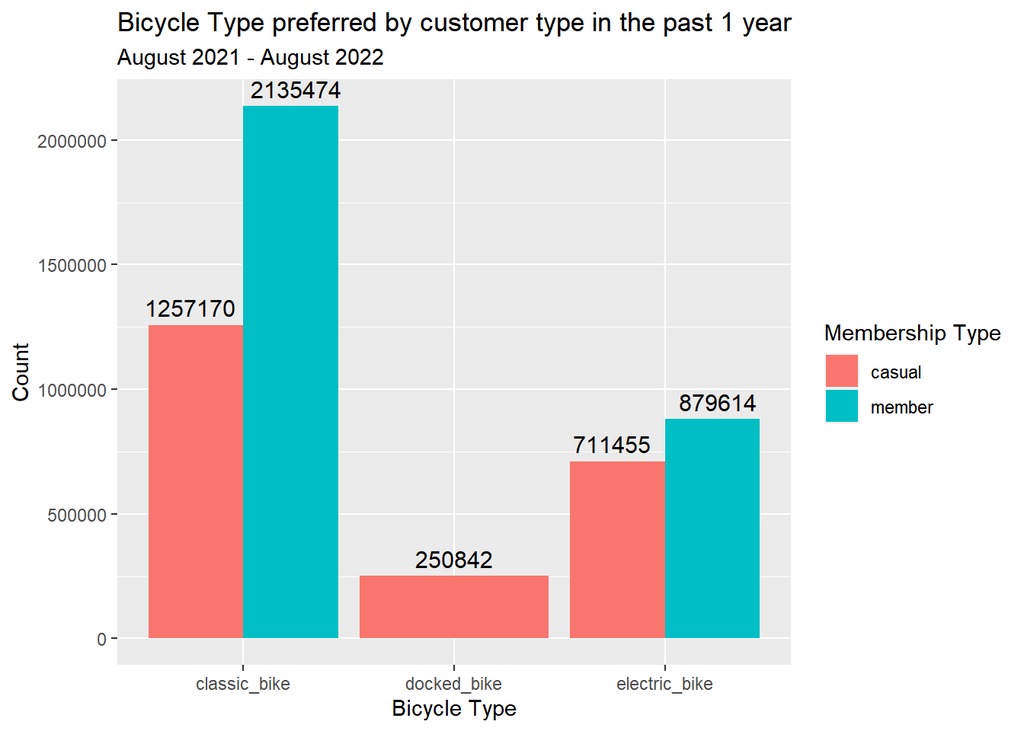

```r
data_combined %>%
  group_by(member_casual, rideable_type) %>%
  summarise(total_rides = n()) %>%
  ggplot(aes(x = rideable_type, y = total_rides, fill = member_casual)) +
  geom_col(position = position_dodge (width = 0.9) , width = 0.9) + labs (
    x = "Bicycle Type",
    y = "Count",
    title = "Bicycle Type preferred by customer type in the past 1 year",
    subtitle = "August 2021 - August 2022",
    fill = "Membership Type"
  ) +
  geom_text(
    aes(label = total_rides),
    position = position_dodge(1),
    vjust = -0.5,
    hjust = 0.5,
    size = 4
  )
```

## Conclusion

#### The Key Point

- Casual riders ride more on weekends, Member ride consistently throughout the weeks.
- Casual riders have twice the average minutes of member riders.
- Winter months have less customer.
- 42.4% of the riders are casual type.
- Docked bike is the less used type of bike, and only used by some casual riders.

## Possible Recommendation

- Reduce the amount of docked bike to minimize cost.
- Give annual casual riders a discount to upgrade them to annual membership.
- Advertise more on being an annual membership benefit.
- Make the weekend price higher for the casual member so that they consider upgrading to member.
- Gave discount or heating equipment on bike ride during winter months.